# Final_Project

```python
# Imports
import pandas as pd

data_pitching = pd.read_csv("Pitching.csv")
data_pitching = data_pitching[data_pitching.yearID >= 2000][data_pitching.yearID <= 2016]

data_salaries = pd.read_csv("Salaries.csv")
data_salaries = data_salaries[data_salaries.yearID >= 2000][data_salaries.yearID <= 2016]

data_pitching = data_pitching.reset_index()
data_salaries = data_salaries.reset_index()

salaries = []
#print(data_salaries.index[(data_salaries['playerID'] == 'zimmery01') & (data_salaries['yearID'] == 2016)])
#print(data_salaries.loc[data_salaries.index[(data_salaries['playerID'] == 'zimmery01') & (data_salaries['yearID'] == 2016)][0]].at['salary'])
for i, row in data_pitching.iterrows():
  if data_pitching.at[i, 'playerID'] in data_salaries['playerID'].values:
    print(data_salaries.index[(data_salaries['playerID'] == row.playerID) & (data_salaries['yearID'] == row.yearID)])
    salaries.append(data_salaries.loc[data_salaries.index[(data_salaries['playerID'] == row.playerID) & (data_salaries['yearID'] == row.yearID)][0]].at['salary'])

data_pitching['salaries'] = salaries

#### JOSH ####
# Get Pitching data


#data_pitching
#data_salaries
data_pitching
#### Plots ####
# Pitching - Josh
# Hitting - Austin
```

[output not shown]

[output not shown]

What we need:

1) Plots a) Histogram i) X axis - year before, year after ii) Y axis - total amount of players with 3.00 ERA below b) Scatterplot i) X axis - all players ii) Y- axis - specific stat iii) Grouped by team? iv) Color coded by year before/year after

```python
# Imports
import pandas as pd
import matplotlib.pyplot as plt


data_batting = pd.read_csv("Batting.csv")
data_batting = data_batting[data_batting.yearID >= 1985][data_batting.yearID <= 2016]
data_fielding = pd.read_csv("Fielding.csv")
data_fielding = data_fielding[data_fielding.yearID >= 1985][data_fielding.yearID <= 2016]
data_salaries = pd.read_csv("Salaries.csv")
data_salaries = data_salaries[data_salaries.yearID >= 1985][data_salaries.yearID <= 2016]
```

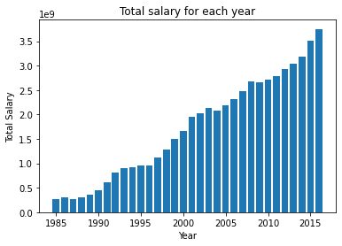

```python
from pandas.tseries.offsets import YearEnd
# Create violin plot of HR by year

def round_down_5(row):
  n = row['yearID']
  return n//5*5

data_salaries['5_year_span_start'] = data_salaries.apply (lambda row: round_down_5(row), axis=1)

salaries = {}

for year in data_salaries['yearID'].unique():
  salaries[year] = 0

for index, row in data_salaries.iterrows():
  salaries[row.yearID] += row.salary

plt.bar(salaries.keys(), salaries.values())
plt.ylabel("Total Salary")
plt.xlabel("Year")
plt.title("Total salary for each year")
plt.show()
```

Clearly the total salary is increasing per year. This means it would be pointless to compare salaries between years. We will thus treat each player's salary as a fraction of the total payroll for that year.

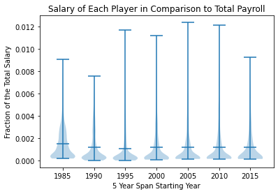

```python
def salary_fraction (row):
  return row.salary / salaries[row.yearID]

data_salaries['salary_fraction'] = data_salaries.apply (lambda row: salary_fraction(row), axis=1)

salaries_fractions = {}

for span in data_salaries['5_year_span_start'].unique():
  salaries_fractions[span] = []

for index, row in data_salaries.iterrows():
  salaries_fractions[row['5_year_span_start']].append(row.salary_fraction)

fig_res, ax_res = plt.subplots()

#Create the plot
ax_res.violinplot(salaries_fractions.values(),salaries_fractions.keys(),widths=4,showmeans=True)
ax_res.set_xlabel("5 Year Span Starting Year")
ax_res.set_ylabel("Fraction of the Total Salary")
ax_res.set_title("Salary of Each Player in Comparison to Total Payroll")
```

Now let's add that data to our batters dataframe.

```python
data_all = data_batting.merge(
     data_salaries,
     on=["yearID", "playerID"],
     how="left",
 )

data_all = data_all.merge(
     data_fielding,
     on=["yearID", "playerID"],
     how="left",
 )

data_all = data_all.dropna(subset = ['salary'])

data_all = data_all[data_all.AB > 100]

data_all.head()
```

|  | playerID | yearID | stint_x | teamID_x | lgID_x | G_x | AB | R | H | 2B | ... | InnOuts | PO | A | E | DP | PB | WP | SB_y | CS_y | ZR |
| --- | --- | --- | --- | --- | --- | --- | --- | --- | --- | --- | --- | --- | --- | --- | --- | --- | --- | --- | --- | --- | --- |
| 7 | aguaylu01 | 1985 | 1 | PHI | NL | 91 | 165 | 27 | 46 | 7 | ... | 192.0 | 27.0 | 25.0 | 1.0 | 5.0 | NaN | NaN | NaN | NaN | NaN |
| 8 | aguaylu01 | 1985 | 1 | PHI | NL | 91 | 165 | 27 | 46 | 7 | ... | 126.0 | 4.0 | 16.0 | 0.0 | 1.0 | NaN | NaN | NaN | NaN | NaN |
| 9 | aguaylu01 | 1985 | 1 | PHI | NL | 91 | 165 | 27 | 46 | 7 | ... | 1052.0 | 61.0 | 117.0 | 8.0 | 21.0 | NaN | NaN | NaN | NaN | NaN |
| 18 | almonbi01 | 1985 | 1 | PIT | NL | 88 | 244 | 33 | 66 | 17 | ... | 74.0 | 25.0 | 1.0 | 2.0 | 3.0 | NaN | NaN | NaN | NaN | NaN |
| 19 | almonbi01 | 1985 | 1 | PIT | NL | 88 | 244 | 33 | 66 | 17 | ... | 111.0 | 2.0 | 4.0 | 1.0 | 0.0 | NaN | NaN | NaN | NaN | NaN |

5 rows × 43 columns

```python
data_all.columns
```

```
Index(['playerID', 'yearID', 'stint_x', 'teamID_x', 'lgID_x', 'G_x', 'AB', 'R',
       'H', '2B', '3B', 'HR', 'RBI', 'SB_x', 'CS_x', 'BB', 'SO', 'IBB', 'HBP',
       'SH', 'SF', 'GIDP', 'teamID_y', 'lgID_y', 'salary', '5_year_span_start',
       'salary_fraction', 'stint_y', 'teamID', 'lgID', 'POS', 'G_y', 'GS',
       'InnOuts', 'PO', 'A', 'E', 'DP', 'PB', 'WP', 'SB_y', 'CS_y', 'ZR'],
      dtype='object')
```

```python
def ops (row):
  slugging = (row['H'] + row['2B'] + 2 * row['3B'] + 3 * row['HR']) / row['AB']
  OBP = (row['BB'] + row['IBB'] + row['HBP'] + row['H']) / (row['AB'] + row['BB'] + row['IBB'] + row['SH'] + row['SF'] + row['HBP'])
  return slugging + OBP

data_all['OPS'] = data_all.apply (lambda row: ops(row), axis = 1)

data_all['AVG'] = data_all['H'] / data_all['AB']

data_all['FPCT'] = (data_all['A'] + data_all['PO']) / (data_all['A'] + data_all['E'] + data_all['PO'])

data_all = data_all.dropna(subset = ['FPCT'])

data_all
```

|  | playerID | yearID | stint_x | teamID_x | lgID_x | G_x | AB | R | H | 2B | ... | E | DP | PB | WP | SB_y | CS_y | ZR | OPS | AVG | FPCT |
| --- | --- | --- | --- | --- | --- | --- | --- | --- | --- | --- | --- | --- | --- | --- | --- | --- | --- | --- | --- | --- | --- |
| 7 | aguaylu01 | 1985 | 1 | PHI | NL | 91 | 165 | 27 | 46 | 7 | ... | 1.0 | 5.0 | NaN | NaN | NaN | NaN | NaN | 0.852033 | 0.278788 | 0.981132 |
| 8 | aguaylu01 | 1985 | 1 | PHI | NL | 91 | 165 | 27 | 46 | 7 | ... | 0.0 | 1.0 | NaN | NaN | NaN | NaN | NaN | 0.852033 | 0.278788 | 1.000000 |
| 9 | aguaylu01 | 1985 | 1 | PHI | NL | 91 | 165 | 27 | 46 | 7 | ... | 8.0 | 21.0 | NaN | NaN | NaN | NaN | NaN | 0.852033 | 0.278788 | 0.956989 |
| 18 | almonbi01 | 1985 | 1 | PIT | NL | 88 | 244 | 33 | 66 | 17 | ... | 2.0 | 3.0 | NaN | NaN | NaN | NaN | NaN | 0.738752 | 0.270492 | 0.928571 |
| 19 | almonbi01 | 1985 | 1 | PIT | NL | 88 | 244 | 33 | 66 | 17 | ... | 1.0 | 0.0 | NaN | NaN | NaN | NaN | NaN | 0.738752 | 0.270492 | 0.857143 |
| ... | ... | ... | ... | ... | ... | ... | ... | ... | ... | ... | ... | ... | ... | ... | ... | ... | ... | ... | ... | ... | ... |
| 61631 | youngch04 | 2016 | 1 | BOS | AL | 76 | 203 | 29 | 56 | 18 | ... | 0.0 | 0.0 | NaN | NaN | NaN | NaN | NaN | 0.849960 | 0.275862 | 1.000000 |
| 61640 | zimmery01 | 2016 | 1 | WAS | NL | 115 | 427 | 60 | 93 | 18 | ... | 4.0 | 88.0 | NaN | NaN | NaN | NaN | NaN | 0.643528 | 0.217799 | 0.995556 |
| 61641 | zobribe01 | 2016 | 1 | CHN | NL | 147 | 523 | 94 | 142 | 31 | ... | 0.0 | 0.0 | NaN | NaN | NaN | NaN | NaN | 0.834832 | 0.271511 | 1.000000 |
| 61642 | zobribe01 | 2016 | 1 | CHN | NL | 147 | 523 | 94 | 142 | 31 | ... | 7.0 | 52.0 | NaN | NaN | NaN | NaN | NaN | 0.834832 | 0.271511 | 0.983871 |
| 61643 | zobribe01 | 2016 | 1 | CHN | NL | 147 | 523 | 94 | 142 | 31 | ... | 0.0 | 0.0 | NaN | NaN | NaN | NaN | NaN | 0.834832 | 0.271511 | 1.000000 |

20753 rows × 46 columns

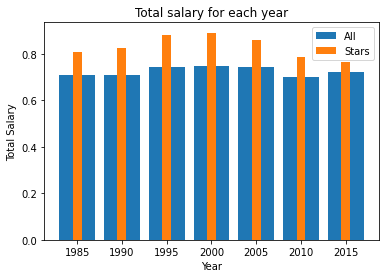

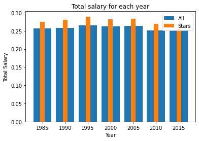

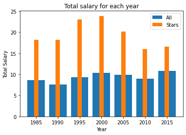

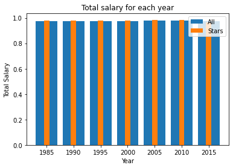

```python
data = data_all[data_all['salary_fraction'] > 0.004]

for stat in ['OPS', 'AVG', 'HR', 'FPCT']:
  player_stats = {}
  player_stats_stars = {}

  for span in data['5_year_span_start'].unique():
    player_stats[span] = data_all.loc[data_all['5_year_span_start'] == span, stat].mean()
    player_stats_stars[span] = data.loc[data['5_year_span_start'] == span, stat].mean()


  plt.bar(player_stats.keys(), player_stats.values(), 4, label = "All")
  plt.bar(player_stats.keys(), player_stats_stars.values(), 1, label = "Stars")
  plt.ylabel("Total Salary")
  plt.xlabel("Year")
  plt.title("Total salary for each year")
  plt.legend()
  plt.show()
```

```python
stat_means = {}
for stat in ['OPS', 'AVG', 'HR', 'FPCT']:
  player_stats = {}
  stat_means[stat] = {}

  for span in data_all['5_year_span_start'].unique():
    player_stats[span] = data_all.loc[data_all['5_year_span_start'] == span, stat].mean()
    stat_means[stat][span] = data_all.loc[data_all['5_year_span_start'] == span, stat].mean()

def get_interaction (row):
  span = row['5_year_span_start']
  norm_ops = row['OPS'] / stat_means['OPS'][span]
  norm_avg = row['AVG'] / stat_means['AVG'][span]
  norm_hr = row['HR'] / stat_means['HR'][span]
  norm_fpct = row['FPCT'] / stat_means['FPCT'][span]
  return ((norm_ops + norm_avg + norm_hr) / 3 + norm_fpct) / 2


data['interaction_term'] = data.apply(lambda row: get_interaction(row), axis = 1)
data_all['interaction_term'] = data_all.apply(lambda row: get_interaction(row), axis = 1)

data
```

|  | playerID | yearID | stint_x | teamID_x | lgID_x | G_x | AB | R | H | 2B | ... | DP | PB | WP | SB_y | CS_y | ZR | OPS | AVG | FPCT | interaction_term |
| --- | --- | --- | --- | --- | --- | --- | --- | --- | --- | --- | --- | --- | --- | --- | --- | --- | --- | --- | --- | --- | --- |
| 208 | cartega01 | 1985 | 1 | NYN | NL | 149 | 555 | 83 | 156 | 17 | ... | 2.0 | NaN | NaN | NaN | NaN | NaN | 0.868874 | 0.281081 | 1.000000 | 1.521795 |
| 209 | cartega01 | 1985 | 1 | NYN | NL | 149 | 555 | 83 | 156 | 17 | ... | 11.0 | 5.0 | NaN | 99.0 | 51.0 | NaN | 0.868874 | 0.281081 | 0.992241 | 1.517809 |
| 231 | ceyro01 | 1985 | 1 | CHN | NL | 145 | 500 | 64 | 116 | 18 | ... | 21.0 | NaN | NaN | NaN | NaN | NaN | 0.734353 | 0.232000 | 0.943089 | 1.234918 |
| 241 | clarkja01 | 1985 | 1 | SLN | NL | 126 | 442 | 71 | 124 | 26 | ... | 102.0 | NaN | NaN | NaN | NaN | NaN | 0.910687 | 0.280543 | 0.988294 | 1.331140 |
| 242 | clarkja01 | 1985 | 1 | SLN | NL | 126 | 442 | 71 | 124 | 26 | ... | 0.0 | NaN | NaN | NaN | NaN | NaN | 0.910687 | 0.280543 | 1.000000 | 1.337153 |
| ... | ... | ... | ... | ... | ... | ... | ... | ... | ... | ... | ... | ... | ... | ... | ... | ... | ... | ... | ... | ... | ... |
| 61496 | uptonju01 | 2016 | 1 | DET | AL | 153 | 570 | 81 | 140 | 28 | ... | 0.0 | NaN | NaN | NaN | NaN | NaN | 0.778108 | 0.245614 | 0.985455 | 1.326564 |
| 61539 | vottojo01 | 2016 | 1 | CIN | NL | 158 | 556 | 101 | 181 | 34 | ... | 124.0 | NaN | NaN | NaN | NaN | NaN | 0.996892 | 0.325540 | 0.993765 | 1.403123 |
| 61569 | werthja01 | 2016 | 1 | WAS | NL | 143 | 525 | 84 | 128 | 28 | ... | 1.0 | NaN | NaN | NaN | NaN | NaN | 0.752126 | 0.243810 | 0.995169 | 1.169652 |
| 61577 | wietema01 | 2016 | 1 | BAL | AL | 124 | 423 | 48 | 103 | 17 | ... | 6.0 | 1.0 | NaN | 43.0 | 23.0 | NaN | 0.712209 | 0.243499 | 0.988197 | 1.094785 |
| 61618 | wrighda03 | 2016 | 1 | NYN | NL | 37 | 137 | 18 | 31 | 8 | ... | 5.0 | NaN | NaN | NaN | NaN | NaN | 0.787649 | 0.226277 | 0.952941 | 0.928010 |

1584 rows × 47 columns

[output not shown]

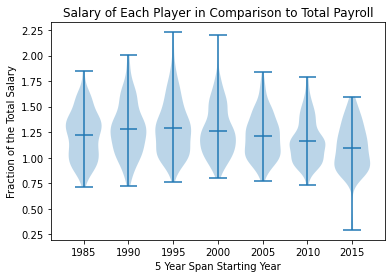

```python
term_means = {}

for index, row in data.iterrows():
  if row['5_year_span_start'] not in term_means.keys():
    term_means[row['5_year_span_start']] = []
  term_means[row['5_year_span_start']].append(row['interaction_term'])

print(term_means.values())

fig_res, ax_res = plt.subplots()

#Create the plot
ax_res.violinplot(term_means.values(), term_means.keys(), widths=4,showmeans=True)
ax_res.set_xlabel("5 Year Span Starting Year")
ax_res.set_ylabel("Fraction of the Total Salary")
ax_res.set_title("Salary of Each Player in Comparison to Total Payroll")
```

[figure not shown]

```python
from sklearn.linear_model import LinearRegression
import numpy as np

x = np.array(data['interaction_term']).reshape(-1,1)
y = np.array(data['salary_fraction']).reshape(-1,1)

#Initialize and fit the model
reg = LinearRegression()
reg.fit(x, y)

plt.plot(x, reg.predict(x))

plt.scatter(data['interaction_term'], data['salary_fraction'])
plt.ylabel("Life expectancy")
plt.xlabel("Year")
plt.title("Life Expectancy by Year")

plt.show()
```

```python
# compute with formulas from the theory
yhat = reg.predict(x)
SS_Residual = sum((y-yhat)**2)
SS_Total = sum((y-np.mean(y))**2)
r_squared = 1 - (float(SS_Residual))/SS_Total
adjusted_r_squared = 1 - (1-r_squared)*(len(y)-1)/(len(y)-x.shape[1]-1)
print(r_squared, adjusted_r_squared)
```

```
[0.03969053] [0.03908351]
```

Conclusions:

There is clearly a difference between the players paid a high amount and those not (see original bar graphs). However, there is a lot of variance within these highly paid players. This is most likely due to the fact that stats are very similar, and small changes can make big differences. Any player playing slightly better than expected can have a big impact, so the players paid a lot, though expected to do very well, might just do well.

[figure not shown]

```python
def round_down_0005(row):
  n = row['salary_fraction'] * 10000
  return n // 5 * 5 / 10000

data_all['salary_bracket'] = data_all.apply (lambda row: round_down_0005(row), axis=1)
data['salary_bracket'] = data.apply (lambda row: round_down_0005(row), axis=1)

brackets = {}

for brack in data_all['salary_bracket'].unique():
  brackets[brack] = data_all.loc[data_all['salary_bracket'] == brack, 'interaction_term'].mean()


y = np.array(list(brackets.keys())).reshape(-1,1)
x = np.array(list(brackets.values())).reshape(-1,1)

#Initialize and fit the model
reg1 = LinearRegression()
reg1.fit(x, y)

plt.plot(x, reg1.predict(x))

plt.scatter(brackets.values(), brackets.keys())
plt.ylabel("Life expectancy")
plt.xlabel("Year")
plt.title("Life Expectancy by Year")

plt.show()
```

```python
# compute with formulas from the theory
yhat = reg1.predict(x)
SS_Residual = sum((y-yhat)**2)
SS_Total = sum((y-np.mean(y))**2)
r_squared = 1 - (float(SS_Residual))/SS_Total
print(r_squared)
```

```
[0.82645974]
```

We see a huge amount of correlation between the salary bracket and the interaction term. This can help us predict which salary bracket a player will be in.

[figure not shown]

```python
x = np.array(list(salaries.keys())).reshape(-1,1)
y = np.array(list(salaries.values())).reshape(-1,1)

#Initialize and fit the model
reg = LinearRegression()
reg.fit(x, y)

plt.plot(x, reg.predict(x))

plt.scatter(salaries.keys(), salaries.values())
plt.ylabel("Life expectancy")
plt.xlabel("Year")
plt.title("Life Expectancy by Year")

plt.show()
```

```python
# compute with formulas from the theory
yhat = reg.predict(x)
SS_Residual = sum((y-yhat)**2)
SS_Total = sum((y-np.mean(y))**2)
r_squared = 1 - (float(SS_Residual))/SS_Total
print(r_squared)
```

```
[0.98450337]
```

```python
def predicted_salary (year, interaction_term):
  interaction_term = interaction_term * 10000 // 5 * 5 / 10000
  return (reg.coef_[0][0] * year + reg.intercept_[0]) * (reg1.coef_[0][0] * interaction_term + reg1.intercept_[0])
```